# 9: Neural Networks, Transfer Learning and Transformer Models

## The Transformer Block

**Figure 1**: A single transformer block

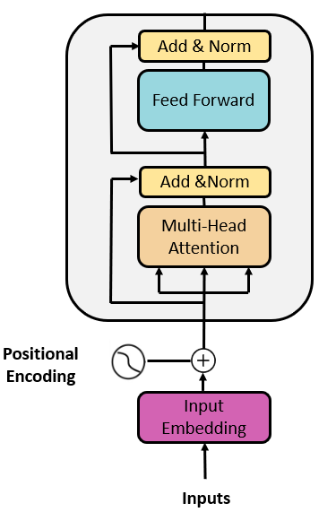

The **attention** mechanism captures relationships between tokens.

- Context-signifiers
  - “I walked to the **bank** of the **river**”
- Adjective-noun relationships
  - “He is a **wreckless** **accountant**”
- Co-references
  - “The **chicken** did not cross the road because **it** was too *tired*”

## Attention mechanism detail

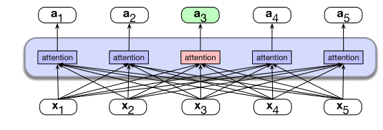

- In each transformer block, the representation for token i is updated by ‘attending to’ the representations of other tokens.
- The amount of attention paid to token j when updating token i’s representation is determined (roughly) by how similar their input representations are.
- Pays more attention to:
  - nearer words (due to positional embeddings)
  - semantically related words (even if further away)

## Attention mechanism detail

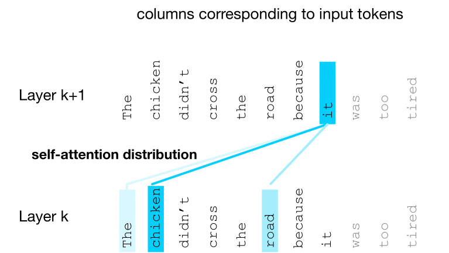

## The Transformer Architecture

The full transformer model consists of several stacked transformer block.

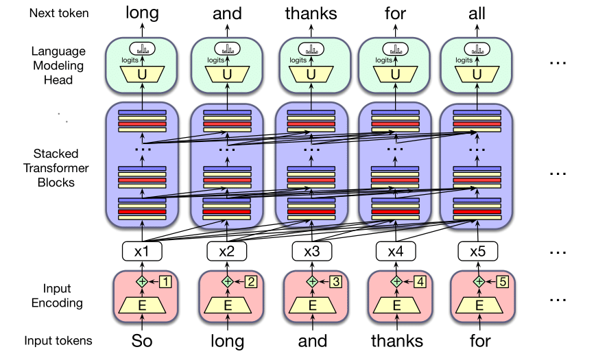

## Summary so far

1. Neural networks **in general** are complex, non-linear functions that map numerical inputs to numerical outputs.
- They are composed of units that perform simpler calculations as part of a sequence.
- The hidden layers of a NN construct a **latent representation** of the data
2. Neural networks can be **trained** using **gradient descent** which involves iteratively updating parameters based on labelled examples.
3. Neural networks can be applied to **language modelling**, where:
- Inputs are one-hot encodings / precomputed word embeddings
- Outputs a probability distribution for the missing or next word.
- There are a variety of possible **architectures**
4. The **transformer architecture** is a particularly effective architecture for NLP

# Transfer learning

## How can we use these models?

1. **Problems:**
- Neural language models are designed to predict the next/missing word. But that’s not what social scientists do!
- Training models with so many parameters is expensive and time consuming.
2. **Solution: Transfer Learning**
- Use knowledge learned from one task (causal/masked language modelling) to boost performance on a related task.
- Makes efficient use of computational resources
- Makes efficient use of labelled data

## Terminology

1. **Pre-training:** Training a model from scratch (initialise parameters randomly)
2. **Fine-tuning:** Update the parameters of a model that has already been trained on a large amount of data using new training data suited for a new task.
- This might involve **modifying the model architecture**.
  - one-hot encodings $\rightarrow$ contextual embeddings $\rightarrow$ **prob. dist. words**
  - one-hot encodings $\rightarrow$ contextual embeddings $\rightarrow$ **prob. dist. sentiment**

## BERT Pre-training

**Data: 3.3 billion word corpus from…**

- English Wikipedia
- BooksCorpus

**Task 1: Masked language modelling**

**Task 2: Next sentence prediction**

**Figure 1:** *Masked language modelling example*

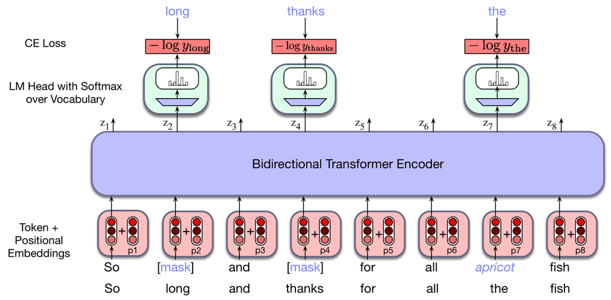

**Figure 2:** *Next sentence prediction example*

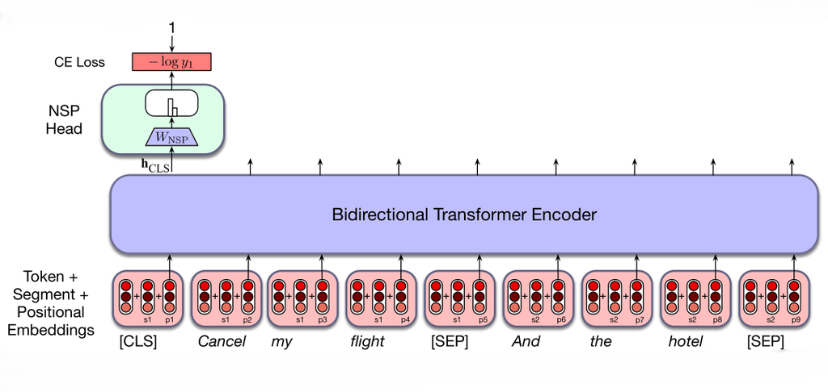

## BERT + Classifier head

**Procedure**

1. **BERT pre-training**
- Masked language modelling (MLM)
- Next sentence prediction (NSP)
2. **Modify architecture:**
1. Remove MLM/NSP head(s)
2. Add a classifier head
3. **Train classifier**

**Figure 1:** *Masked language modelling head*

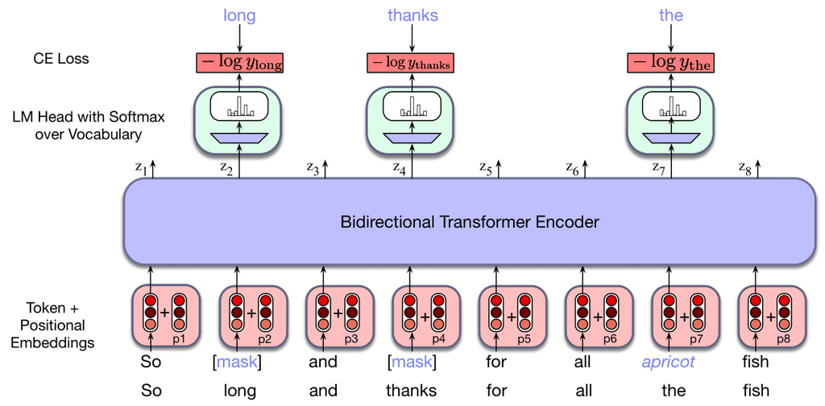

**Figure 2:** *BERT encoder with no head*

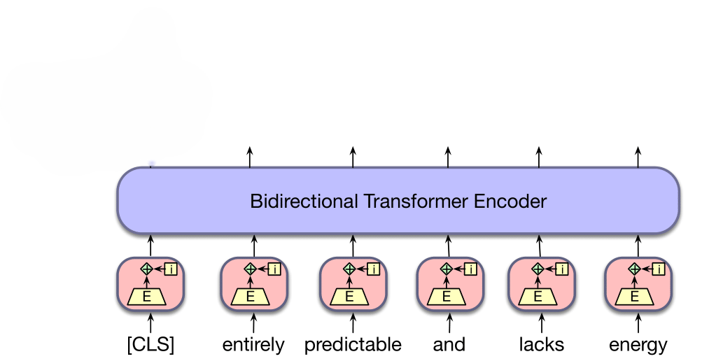

**Figure 3:** *BERT encoder with classification head*

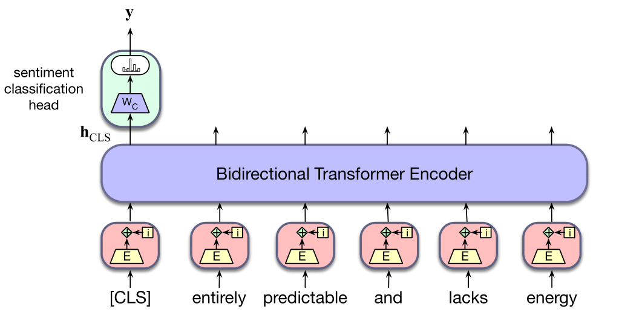

## BERT + Classifier head: Example

1. **Pretraining** (general domain)
- Task: Masked language modelling
- Data: Common Crawl
2. **Training** (downstream tasks)
- Task: classification
- Data: hand-coded paragraphs

| Example text | Label |
| --- | --- |
| Apple’s latest [MASK] model features improved camera capabilities. | iPhone |
| The Eiffel Tower is located in [MASK], France. | Paris |

| Example text | Label |
| --- | --- |
| I’ve never been so delighted | positive |
| This is unbearably boring | negative |

## BERT Variations

| Model | Key Differences from BERT | Training Objective | Parameters |
| --- | --- | --- | --- |
| **BERT** | Baseline model | Masked Language Modeling (MLM), Next Sentence Prediction (NSP) | Base 110M, Large 340M |
| **RoBERTa** | No NSP, more training data, dynamic masking | MLM only | Base 125M, Large 355M |
| **DistilBERT** | Distilled version of BERT | Masked Language Modeling (MLM) only | 66M |
| **ALBERT** | Parameter sharing | Masked Language Modeling (MLM) and sentence order prediction (SOP) | Base 12M, 18M |

## Domain adaptive pretraining

**Problem:** Limits of general pretraining

- Domain specific words are not included as full words in vocabulary (i.e. broken into subwords)
  - e.g. ‘CO2’, ‘estimation’, ‘ecological’
- Words may have domain-specific meanings that do not occur frequently enough in pretraining
  - e.g. ‘derivative’ in maths vs finance vs literature

**Solution:** Additional pre-training on corpus drawn from specific domain - e.g. FinBERT (finance), LegalBert (law), MedBert (medicine)

## ClimateBERT

1. **Pretraining** (general domain)
- Task: Masked language modelling
- Data: Common Crawl
2. **Domain adaptive pretraining** (climate specific)
- Task: Masked language modelling
- Data: climate-related texts
3. **Training** (downstream tasks)
- Task: classification
- Data: hand-coded paragraphs

| Example text | Label |
| --- | --- |
| Apple’s latest [MASK] model features improved camera capabilities. | iPhone |
| The Eiffel Tower is located in [MASK], France. | Paris |

| Example text | Label |
| --- | --- |
| The atmosphere is a global commons that responds to many types of [MASK] | emissions |
| Adaptations are most likely to be stimulated by [MASK] variability | climatic |

| Example text | Label |
| --- | --- |
| Grid & Infrastructure and Retail today represent the energy world of tomorrow | opportunity |
| ANIC recognizes that increased claims activity resulting from catastrophic events | risk |

## ClimateBERT

Domain adaptive pretraining results in improved performance on masked language modelling within the domain

| Model | Loss |
| --- | --- |
| DistilRoBERTa | 2.238 |
| ClimateBERT | 1.157 |

And on downstream classification tasks…

| Model | Loss |
| --- | --- |
| DistilRoBERTa | 0.242 |
| ClimateBERT | 0.191 |

## NLI as a ‘universal task’

- Knowledge learned from a general task can be reused for a specific task using transfer learning.
- The more similar the pretraining task, the less fine-tuning is needed for downstream tasks.
- Is there a general task that is more similar to social science applications than MLM and NSP?
  - Yes, **natural language inference**!

## What is Natural Language Inference?

- Natural language inference is a *reasoning* task of determining whether a **context** entails/contradicts a **hypothesis**
- $context$ entails $hypothesis$ if $\Pr(hypothesis|context) \approx 1$
- $context$ contradicts $hypothesis$ if $\Pr(hypothesis|context) \approx 0$
- $context$ is neutral w.r.t. $hypothesis$ if $\Pr(hypothesis|context) \approx \Pr(hypothesis)$

| Context (c) | Hypothesis (h) | Status |
| --- | --- | --- |
| We need overseas workers in the NHS | Immigration is a good thing | Entailment |
| Immigrants are taking our jobs | Immigration is a bad thing | Entailment |
| Income taxes should be reduced | Immigration is a good thing | Neutral |
| The government should call an election | Immigration is a bad thing | Neutral |
| We need overseas workers in the NHS | Immigration is a bad thing | Contradiction |
| Immigrants are taking our jobs | Immigration is a good thing | Contradiction |

## How can BERT be used for NLI?

Repurpose NSP head for natural language inference…

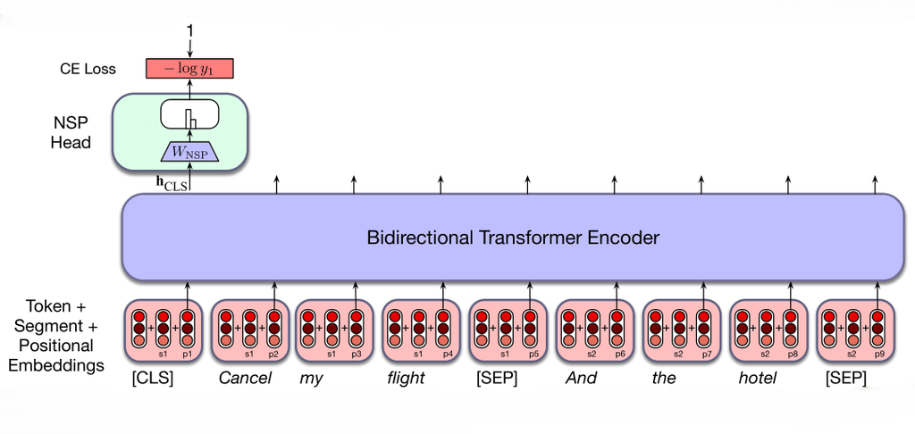

## BERT-NLI

[figure not shown]

## Zero-shot Classification with BERT-NLI

**Example:** classify news headlines into a predefined set of topics {immigration, environment, other}

1. **Define a hypothesis for each category**
- **H1:** The headline is about immigration
- **H2:** The headline is about the environment
- **H3:** The headline is not about immigration or the environment
2. **Concatenate the headlines and hypotheses:**
- e.g. “[CLS] Headline : ’ Net immigration reaches record high ’ [SEP] The headline is about immigration”
- e.g. “[CLS] Headline : ’ Net immigration reaches record high ’ [SEP] The headline is about the environment”
- e.g. “[CLS] Headline : ’ Net immigration reaches record high ’ [SEP] The headline is not about immigration or the environment”
3. **Inference:** Use pre-trained BERT-NLI model to predict probability of entailment for each hypothesis (use softmax to force probabilities to add to 1 for each headline)
- e.g. [0.9, 0.03, 0.07]
4. **Assign headline to most probable hypothesis**

## Fine-tuning BERT-NLI

Fine-tuning BERT-NLI for classification avoids throwing away information between training phases.

**Classical training sequence:**

- Pre-training (MLM + NSP) $\rightarrow$ **Modify architecture** $\rightarrow$ Fine-tune for classification

**BERT-NLI for classification training sequence:**

## Fine-tuning BERT-NLI

Laurer et al (2023) show that fine-tuning BERT-NLI outperforms fine-tuning BERT-base directly at low training same sizes.

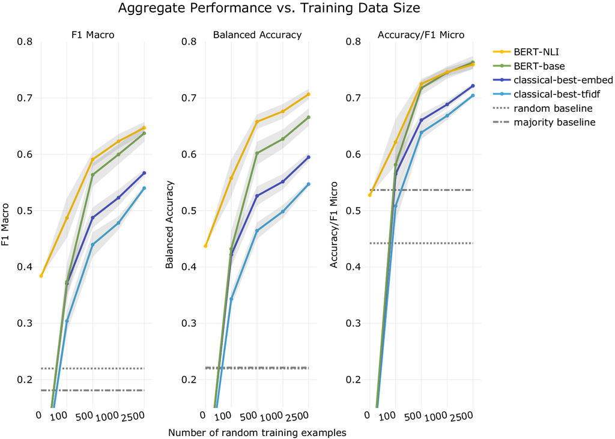

# Practical Considerations

## How can I use a Transformer model for my research?

In terms of software…

- Some Python is required
- HuggingFace API (through Python)

In terms of data… (very rough estimates)

- To train a classifier head from scratch: >1,000 labelled examples
- To fine tune an existing classifier to a new domain: 100-1,000 labelled examples
- To fine tune BERT-NLI for classification: >300 labelled examples
- To perform zero-shot classification: 0 labelled examples (but potentially poor performance)

## HuggingFace

[figure not shown]

## Python for R users

**Interfaces:**

- Google colab* (simplest for beginners)
- Jupiter notebook
- Spyder (similar layout to R studio)

**Managing package dependencies:**

- Temporary environments (used in Google colab)
- Virtual environments (requires terminal operations)
- Conda environments

**Key packages:**

- `pandas`: dataframe structures (similar to `dplyr` and `tidyr`)
- `numpy`: efficient numerical computing (vectorised computations as in R)
- `sklearn`: machine learning functions
- `transformers`: by HuggingFace (no R equivalent!)

# Summary

## Key takeaways

- Neural networks - in particular, **transformer models** - underpin recent advancements in NLP and AI
- Social scientists can use transformer models for better classification through **transfer learning**
  - BERT $\rightarrow$ finetune classifier head
  - BERT $\rightarrow$ Domain adaptive pretraining $\rightarrow$ finetune classifier head
  - BERT $\rightarrow$ BERT-NLI $\rightarrow$ finetune NLI head for classification
- We can implement this using the `transformers` package in Python, alongside HuggingFace.

## Next week

How can **generative** language models be used directly for social science?

[figure not shown]

PUBL0099